# Normalization

Rosie

25/10/2018

Today I will normalize my data using the Watt Fabricius method.

### Check the data

Rename the data:

```r
load("alldata_oct24.Rdata")
data <- alldata_oct24
```

Check the structure of the data:

```r
str(data)
```

```
## 'data.frame':    9303 obs. of  26 variables:
##  $ X           : int  1 2 3 4 5 6 7 8 9 10 ...
##  $ sound_label : Factor w/ 7 levels "face","fleece",..: 4 1 4 4 1 6 2 6 1 4 ...
##  $ sound_start : num  4.82 14.6 58.8 59.31 78.93 ...
##  $ sound_end   : num  4.89 14.68 58.94 59.41 79.05 ...
##  $ word        : Factor w/ 918 levels " TYPE","((ALLAI))",..: 913 503 527 298 510 623 708 434 693 747 ...
##  $ utterance   : Factor w/ 5242 levels "'cos I have choose you",..: 45 4912 3083 3083 1318 3461 3569 4642 4213 3781 ...
##  $ F1_20       : num  549 644 732 560 572 ...
##  $ F1_35       : num  553 658 748 626 564 ...
##  $ F1_50       : num  565 645 708 608 537 ...
##  $ F1_65       : num  575 619 669 592 476 ...
##  $ F1_80       : num  593 608 654 580 418 ...
##  $ F2_20       : num  1548 2081 1598 1943 2410 ...
##  $ F2_35       : num  1558 2116 1522 1819 2434 ...
##  $ F2_50       : num  1567 2241 1442 1844 2532 ...
##  $ F2_65       : num  1599 2263 1398 1854 2594 ...
##  $ F2_80       : num  1589 2118 1404 1830 2692 ...
##  $ participant : Factor w/ 35 levels "Ali","Amanda",..: 19 19 19 19 19 19 19 19 19 19 ...
##  $ duration    : num  0.0679 0.079 0.147 0.1012 0.119 ...
##  $ changeF2    : num  41.1 37.3 -193.9 -113.1 281.8 ...
##  $ changeF1    : num  44.1 -36.2 -77.4 20.7 -153.8 ...
##  $ trajectory  : num  60.2 52 208.8 114.9 321.1 ...
##  $ gender      : Factor w/ 2 levels "F","M": 1 1 1 1 1 1 1 1 1 1 ...
##  $ changeF1norm: num  649 -459 -527 204 -1293 ...
##  $ changeF2norm: num  605 473 -1319 -1117 2368 ...
##  $ traj_norm   : num  888 659 1420 1135 2698 ...
##  $ child       : Factor w/ 2 levels "child","teen": 2 2 2 2 2 2 2 2 2 2 ...
```

Get rid of X:

```r
data$X <- NULL
```

For the TRAP and FLEECE vowels, I want means across the vowel duration, not time-specific measurements. So I will create new variables meanF1 and meanF2.

```r
library(dplyr)
data <- data %>% mutate(meanF1 = (F1_20+F1_35+F1_50+F1_65+F1_80)/5)
data <- data %>% mutate(meanF2 = (F2_20+F2_35+F2_50+F2_65+F2_80)/5)
```

### Create new variables to be used in normalization

The normalization procedure requires each speaker’s

1. mean F1 and F2 for FLEECE
2. mean F1 for TRAP
3. Hypothetical /u/, where both F1 and F2 = the F1 for FLEECE

Create vector of speakers:

```r
speakers <- levels(data$participant)
```

For loop:

```r
formant1 <- vector()
formant2 <- vector()
for(i in speakers){
  speaker <- subset(data, participant==i)
  fleece <- subset(speaker, sound_label=="fleece")
  meanFleeceF1 = mean(fleece$meanF1)
  formant1 <- append(formant1, meanFleeceF1)
  meanFleeceF2 = mean(fleece$meanF2)
  formant2 <- append(formant2, meanFleeceF2)
}
```

Bind these together into a dataframe:

```r
newdata <- cbind(speakers, formant1, formant2)
newdata <- as.data.frame(newdata)
```

Change the column names to make them clear:

```r
colnames(newdata) <- c("speaker", "FLEECEF1", "FLEECEF2")
```

Find each speaker’s mean F1 for TRAP:

```r
formant1b <- vector()
formant_trap_b <- vector()
for(i in speakers){
  speaker <- subset(data, participant==i)
  trap <- subset(speaker, sound_label=="trap")
  meanTrapF1 = mean(trap$meanF1)
  meanTrapF2 = mean(trap$meanF2)
  formant1b <- append(formant1b, meanTrapF1)
  formant_trap_b <- append(formant_trap_b, meanTrapF2)
}
```

Check:

```r
print(formant1b)
```

```
##  [1]  705.9460  863.0180  680.2054  948.4652  747.3192  631.7340  578.4680
##  [8] 1075.7652  921.0698 1064.1520 1143.9725 1115.7174  741.0484  738.5172
## [15]  823.8070  626.3323  603.4937  703.9744  817.6363  794.8460 1000.7784
## [22]  985.8871 1191.5858 1104.7735  991.6209 1046.6040  682.5777  705.5954
## [29]  651.3702  648.9357  629.0664  837.0955  752.0609  609.7155  575.2387
```

```r
print(formant_trap_b)
```

```
##  [1] 1475.866 1564.086 1425.932 1608.601 1391.432 1316.447 1361.764
##  [8] 2219.200 1802.506 2129.018 1729.073 1910.706 1430.656 1394.711
## [15] 1597.946 1324.664 1334.122 1372.051 1656.453 1574.080 1664.562
## [22] 1918.661 2110.651 1950.285 1726.984 1928.685 1320.182 1371.260
## [29] 1470.297 1604.555 1357.143 1551.189 1427.451 1398.365 1228.479
```

Add to the dataframe:

```r
newdata <- cbind(newdata, formant1b, formant_trap_b)
```

And rename it:

```r
colnames(newdata) <- c("participant", "FLEECEF1", "FLEECEF2", "TRAPF1", "TRAPF2")
```

Now hypothetical /u/:

```r
newdata <- newdata %>% mutate(u_F1 = FLEECEF1)
newdata <- newdata %>% mutate(u_F2 = FLEECEF1)
```

```r
str(newdata)
```

```
## 'data.frame':    35 obs. of  7 variables:
##  $ participant: Factor w/ 35 levels "Ali","Amanda",..: 1 2 3 4 5 6 7 8 9 10 ...
##  $ FLEECEF1   : Factor w/ 35 levels "287.477","300.169",..: 14 27 10 19 18 5 2 20 23 34 ...
##  $ FLEECEF2   : Factor w/ 35 levels "1917.68675","1975.065",..: 8 23 12 24 18 6 1 35 26 34 ...
##  $ TRAPF1     : num  706 863 680 948 747 ...
##  $ TRAPF2     : num  1476 1564 1426 1609 1391 ...
##  $ u_F1       : Factor w/ 35 levels "287.477","300.169",..: 14 27 10 19 18 5 2 20 23 34 ...
##  $ u_F2       : Factor w/ 35 levels "287.477","300.169",..: 14 27 10 19 18 5 2 20 23 34 ...
```

Make sure everything is numeric

```r
newdata$FLEECEF1 <- as.numeric(as.character(newdata$FLEECEF1))
newdata$FLEECEF2 <- as.numeric(as.character(newdata$FLEECEF2))
newdata$u_F1 <- as.numeric(as.character(newdata$u_F1))
newdata$u_F2 <- as.numeric(as.character(newdata$u_F2))
```

Grand mean:

```r
s_formant1 <- vector()
s_formant2 <- vector()
for(i in speakers){
  person <- subset(newdata, participant==i)
  s_f1 = (person$FLEECEF1+person$TRAPF1+person$u_F1)/3
  s_f2 = (person$FLEECEF2+person$TRAPF2+person$u_F2)/3
  s_formant1 <- append(s_formant1, s_f1)
  s_formant2 <- append(s_formant2, s_f2)
}
```

Add it to newdata:

```r
newdata <- cbind(newdata, s_formant1, s_formant2)
```

```r
colnames(newdata) <- c("participant", "FLEECEF1", "FLEECEF2", "TRAPF1", "TRAPF2", "u_F1", "u_F2", "s_f1", "s_f2")
```

Here goes:

```r
dataX <- merge(data, newdata, by ="participant")
```

Write this to csv:

```r
write.csv(dataX, "normalise_stage1.csv")
```

Create normalized values for the formants:

```r
dataX <- dataX %>% mutate(
  normF1_20 = F1_20/s_f1,
  normF1_35 = F1_35/s_f1,
  normF1_50 = F1_50/s_f1,
  normF1_65 = F1_65/s_f1,
  normF1_80 = F1_80/s_f1,
  normF2_20 = F2_20/s_f2,
  normF2_35 = F2_35/s_f2,
  normF2_50 = F2_50/s_f2,
  normF2_65 = F2_65/s_f2,
  normF2_80 = F2_80/s_f2)
```

Write to csv:

```r
write.csv(dataX, "normalized.csv")
```

# Try plotting with normalized values

Here I will create some of the same plots that I’ve done before with raw formant frequencies.

```r
library(phonR)
library(ggplot2)
```

Check structure of dataframe:

```r
str(dataX)
```

```
## 'data.frame':    9303 obs. of  45 variables:
##  $ participant : Factor w/ 35 levels "Ali","Amanda",..: 1 1 1 1 1 1 1 1 1 1 ...
##  $ sound_label : Factor w/ 7 levels "face","fleece",..: 4 6 4 1 1 7 4 1 4 1 ...
##  $ sound_start : num  153 154 213 225 230 ...
##  $ sound_end   : num  153 154 213 225 231 ...
##  $ word        : Factor w/ 918 levels " TYPE","((ALLAI))",..: 315 434 200 328 388 653 747 21 22 217 ...
##  $ utterance   : Factor w/ 5242 levels "'cos I have choose you",..: 4315 4315 2146 2988 502 1097 3630 3871 3871 3871 ...
##  $ F1_20       : num  527 709 486 485 539 ...
##  $ F1_35       : num  482 769 497 442 490 ...
##  $ F1_50       : num  546 795 472 441 465 ...
##  $ F1_65       : num  491 798 528 425 572 ...
##  $ F1_80       : num  507 798 596 380 608 ...
##  $ F2_20       : num  1318 1435 1516 2213 2087 ...
##  $ F2_35       : num  1314 1415 1479 2076 2185 ...
##  $ F2_50       : num  1428 1400 1428 2232 2219 ...
```

[output cut: 31 more lines]

Vowel plot:

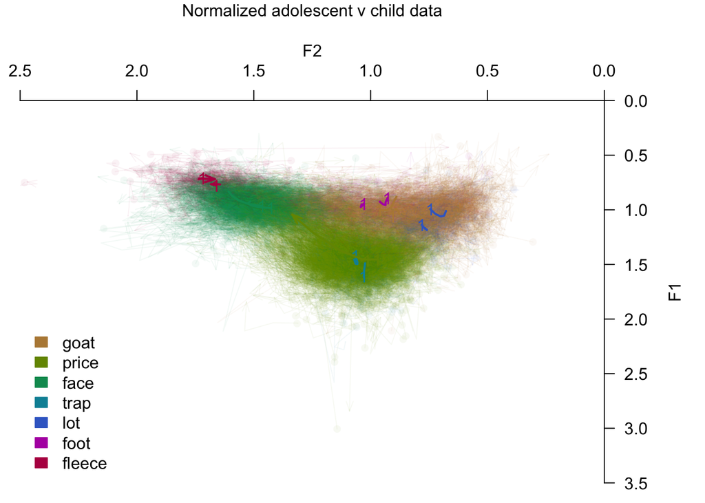

```r
with(dataX, plotVowels(cbind(normF1_20, normF1_35, normF1_50, normF1_65, normF1_80), cbind(normF2_20, normF2_35, normF2_50, normF2_65, normF2_80), sound_label, group=child, alpha.tokens=0.05, plot.means=TRUE, pch.means=1, alpha.means=1, var.col.by = sound_label, pretty=TRUE, diph.arrows=TRUE, legend.kwd = "bottomleft", main="Normalized adolescent v child data"))
```

A scatterplot of all vowel tokens:

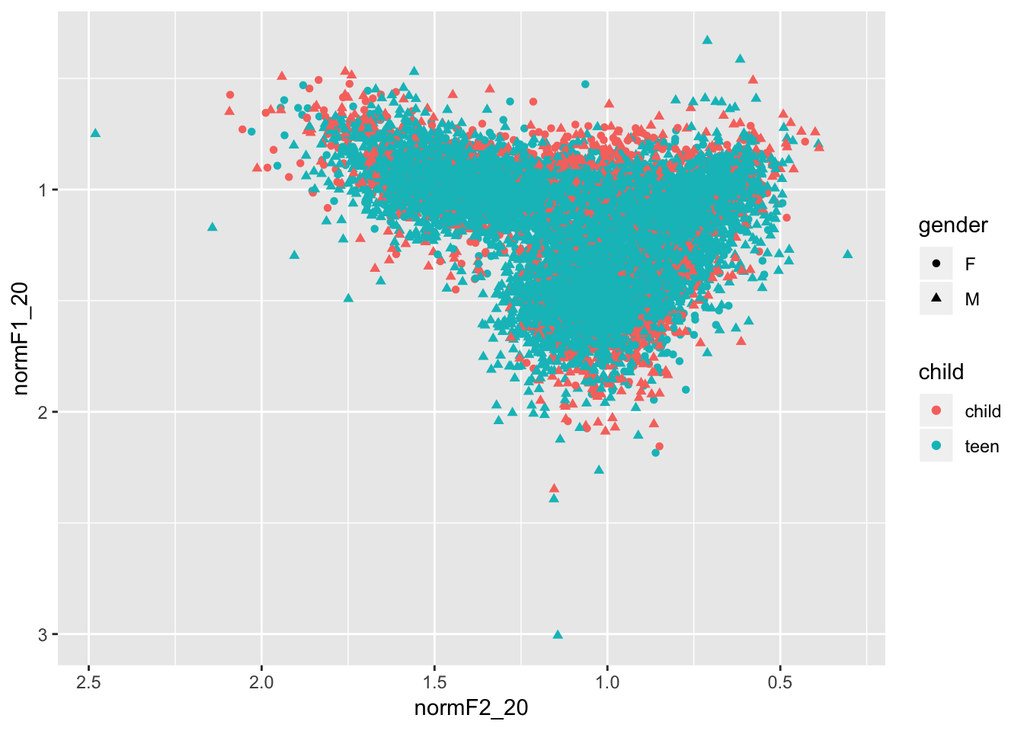

```r
ggplot(dataX, aes(x=normF2_20, y=normF1_20))+geom_point(aes(color=child, shape=gender))+scale_x_reverse()+scale_y_reverse()
```

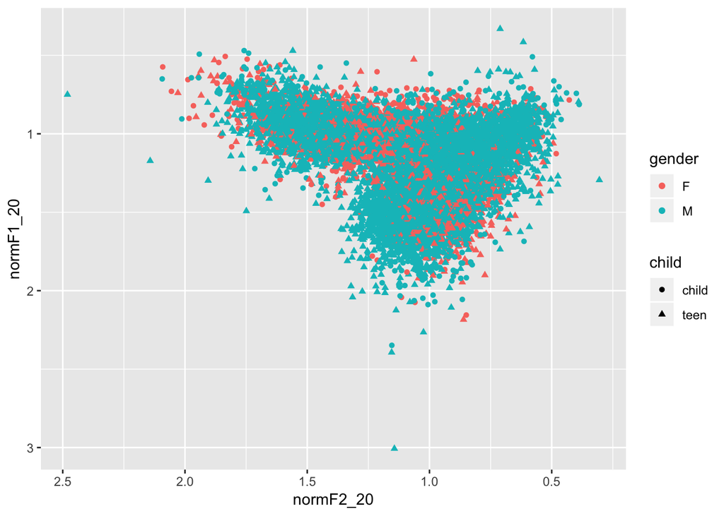

```r
ggplot(dataX, aes(x=normF2_20, y=normF1_20))+geom_point(aes(color=gender, shape=child))+scale_x_reverse()+scale_y_reverse()
```

This is great because it shows us that once the formant frequencies are normalised, the adolescent and child vowel spaces pretty much map onto one another. Compare a version of this plot using unnormalised values:

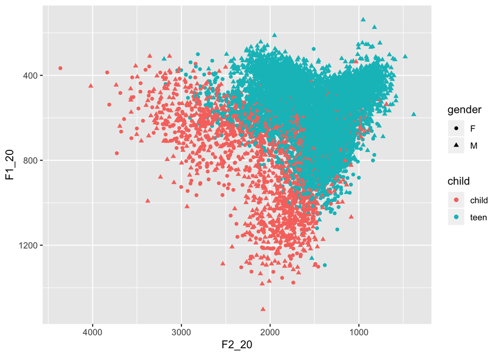

```r
ggplot(dataX, aes(x=F2_20, y=F1_20))+geom_point(aes(color=child, shape=gender))+scale_x_reverse()+scale_y_reverse()
```

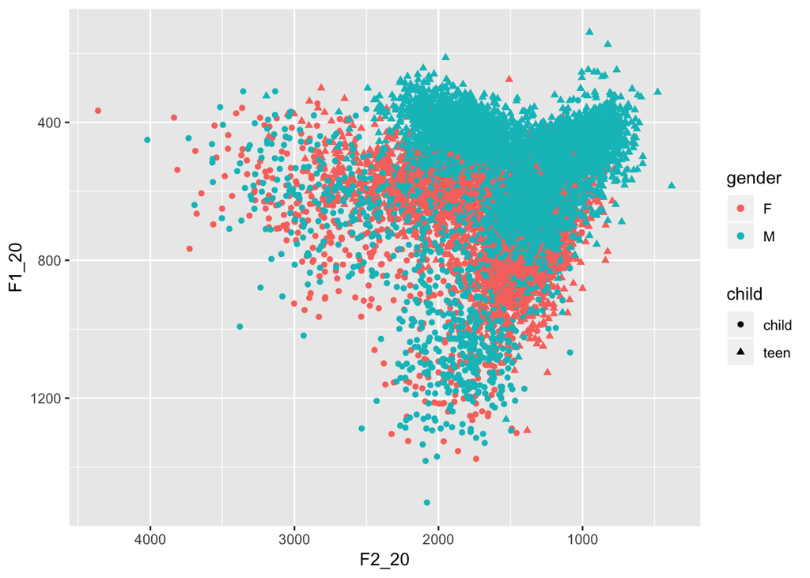

```r
ggplot(dataX, aes(x=F2_20, y=F1_20))+geom_point(aes(color=gender, shape=child))+scale_x_reverse()+scale_y_reverse()
```

## FACE F1

Create the subset:

```r
face <- subset(dataX, sound_label=="face")
```

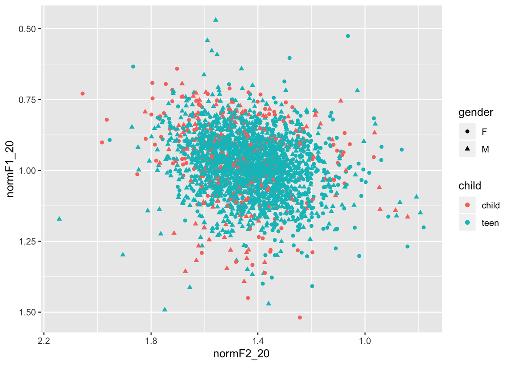

```r
ggplot(face, aes(x=normF2_20, y=normF1_20))+geom_point(aes(color=child, shape=gender))+scale_x_reverse()+scale_y_reverse()
```

Violin plot of onset F1:

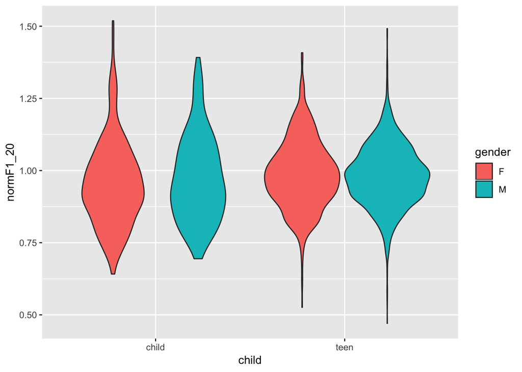

```r
ggplot(face, aes(x=child, y=normF1_20))+geom_violin(aes(fill=gender))
```

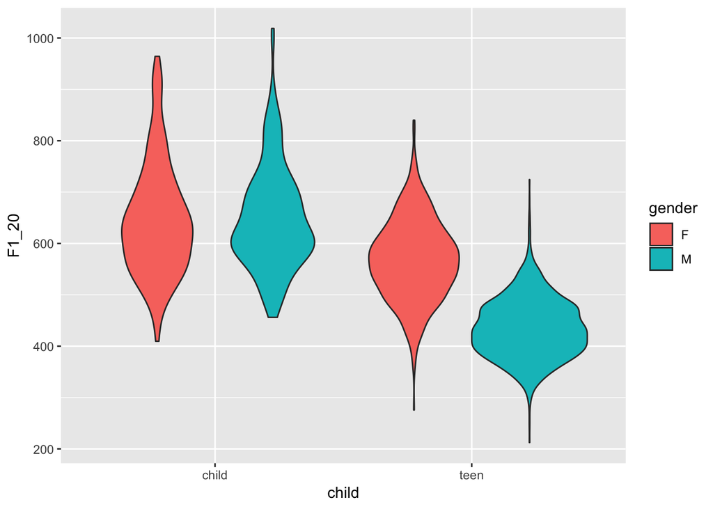

```r
ggplot(face, aes(x=child, y=F1_20))+geom_violin(aes(fill=gender))
```